# PCM data analysis

# 1 Data files

*Raw data files.*

- PatientVars_zip.csv
- R21_Sample_wDxDate.xlsx
- joined_zipcode.xlsx
- Copy.xlsx (Occupation, Primary payer, marital status)
- pcm.xlsx

*Manipulated data files.*

original dx_date_use has been replaced by the new dx_date_use.

## 1.1 In PatientVars_zip3, replace the dx_date_use variable by the new dx_date_use in newDxDate.xlsx.

## 1.2 Poverty data

- “joined_zipcode” file merged to get data about poverty, vacancy, unemployment levels for more zip codes.
  - The main difference from the ‘PCM_preprocessing’ file is that the zip_poverty file (POVERTY, VACANCY, WALKABILITY, UNEMPLOYMENT) is replaced by “joined_zipcode” file.
  - All zip codes in “zip_poverty” file are included in “joined_zipcode” file.
  - And the statistics are strongly matched to each other.
  - Good for the replacement.
- Poverty data (from “joined_zipcode”)
  - For poverty variable, group mean used for each zip code. -> poverty_file_new.xlsx
  - Only 43 zip codes are documented in poverty file. On the other hand, there are 165 zip codes (TN) in Patients file. This will produce too many missing values for the poverty variable.

# 2 Merge datasets

```
## [1] "Date"
```

```
## [1] "Date"
```

```
##    profile_key SURVEY_DATE a_CCMA06
## 1         1665  2009-12-01        0
## 2         1665  2009-12-01        0
## 3         1665  2010-03-17        0
## 4         1665  2010-03-17        0
## 5         1665  2010-09-15        2
## 6         1665  2010-09-15        2
## 7         1665  2010-10-27        0
## 8         1665  2010-10-27        0
## 9         1665  2011-01-12        0
## 10        1665  2011-01-12        0
## 11        1665  2011-07-20        0
## 12        1665  2011-07-20        0
## 13        1665  2012-01-24        0
## 14        1665  2012-01-24        0
```

[output cut: 26 more lines]

```
##   profile_key dx_date_use Marital_Status_at_DX_Desc ssn_wcc_num   zip
## 1        1665  2009-11-09 Married (including common   408621384 38117
## 2        1665  2009-11-09 Married (including common   408621384 38117
##   accession_no state race_NIH race_simple stage_merged stage_simple gender
## 1    201300669    TN    White       White           IA            1      F
## 2    201300669    TN    White       White           IA            1      F
##   age_at_dx age_binary first_chemo first_surgery DEPRESSION DIABETES metastatic
## 1        74          1  2009-03-27    2009-10-13          2        2          Y
## 2        74          1  2009-03-27    2009-10-13          2        2          Y
```

- The cohorts of PCM file and Patients file are equal.

```
## [1] 0
```

```
## [1] 0
```

```
##   Total number of samples = 3835
```

```
##   Number of NA's in dx_date_use in PatientsVar = 167
```

patients_file + copy_file + poverty_file

- Merge patients file and copy file by SSN and then merge it with poverty file by ZIP

```
## [1] 11017    41
```

```
## [1] 5386   41
```

```
## [1] 11025    45
```

## 2.1 Merging datasets naively gives many duplicates and this should be addressed.

N = 3836

```r
mergedData_uniq1 = distinct(mergedData)
dim(mergedData_uniq1)
```

```
## [1] 10686    45
```

```r
length(unique(mergedData_uniq1$profile_key))
```

```
## [1] 3836
```

```
## All distinct states = TN,AR,MS,TX,CO,MO,KY,PA,IL,FL,CA,VA,AL,NA,LA,IN,NC,GA,WV,OH,MD,AZ,WI,CT,WA,SC,NM
```

```r
mergedData_uniq2 = mergedData_uniq1[which(mergedData_uniq1$state=="TN"),]
dim(mergedData_uniq2)
```

```
## [1] 3688   45
```

```r
length(unique(mergedData_uniq2$profile_key))
```

```
## [1] 2628
```

```r
length(unique(mergedData_uniq2$zip))
```

```
## [1] 165
```

```
## [1] 1060
```

```
## [1] 988
```

```
##     zip ssn_wcc_num profile_key dx_date_use Marital_Status_at_DX_Desc
## 1 38117   408621384        1665  2009-11-09 Married (including common
## 2 38117   408621384        1665  2009-11-09 Married (including common
##   accession_no state race_NIH race_simple stage_merged stage_simple gender
## 1    201300669    TN    White       White           IA            1      F
## 2    201300669    TN    White       White           IA            1      F
##   age_at_dx age_binary first_chemo first_surgery DEPRESSION DIABETES metastatic
## 1        74          1  2009-03-27    2009-10-13          2        2          Y
## 2        74          1  2009-03-27    2009-10-13          2        2          Y
##   Accession.Number Vital.Status-Desc
## 1 201300669        Alive
## 2 201300669        Alive
##                                                                                Text.-.Usual.Occupation
## 1 UNKNOWN
## 2 UNKNOWN
##                                                                                  Text.-.Usual.Industry
## 1 UNKNOWN
## 2 UNKNOWN
##   Date.of.Initial.Diagnosis Age.at.Diagnosis Primary.Payer.at.DX-Desc
## 1 20130304                  77               Medicare with supplement
## 2 20130304                  77               Medicare with supplement
##   Marital.Status.at.DX-Desc Tobacco.History-Desc Date.of.First.Surgery
## 1 Married (including common                      20130415
## 2 Married (including common                      20130415
##                                                                                     Cancer.Status-Desc
## 1 Unknown whether this tumor is present
## 2 Unknown whether this tumor is present
##   Date.1st.Recurrence Postal.Code.at.Diagnosis State.at.Diagnosis-Desc
## 1 99999999            38117                    Tennessee
## 2 99999999            38117                    Tennessee
##   Primary.Site-Desc Histo/Behavior.ICD-O-3-Desc Tumor.Size-MM              ER
## 1 Breast, lower-out Lobular carcinoma, NOS      012           Negative/Normal
## 2 Breast, lower-out Lobular carcinoma, NOS      012           Negative/Normal
##                PR              HER2 RT.Site-Desc
## 1 Negative/Normal Positive/Elevated Breast
## 2 Negative/Normal Positive/Elevated
##                                                                                                                                                                                                                                          Type.1st.Recurrence-Desc
## 1 It is unknown whether the disease has recurred or if the patient was ever disease-free
## 2 It is unknown whether the disease has recurred or if the patient was ever disease-free
##   POVERTY VACANCY WALKABILITY UNEMPLOYMENT
## 1  15.626  12.856      24.252        8.512
## 2  15.626  12.856      24.252        8.512
```

```
##    1060  duplicated samples = 1665,73763,75730,77647,85885,86766,86853,86962,87050,87137,87950,88031,88082,88742,89290,89728,90006,90006,90545,91575,91962,94182,94661,96388,96728,101171,101309,101650,102635,102769,102769,103476,103476,104725,104955,104994,105435,106055,106055,108356,108702,109141…
```

```r
profile.split = split(x=which(mergedData_uniq2$profile_key %in% mergedData_uniq2$profile_key[dup_samples]),
                      f=mergedData_uniq2$profile_key[which(mergedData_uniq2$profile_key %in% mergedData_uniq2$profile_key[dup_samples])])

discard_dup = function(x) {
  x[-which.min(apply(mergedData_uniq2[x,],1,function(x) length(which(is.na(x)==T))))]
}
discard_ids = do.call("c",sapply(profile.split,discard_dup))
length(discard_ids)
```

```
## [1] 1060
```

```r
mergedData_uniq3 = mergedData_uniq2[-discard_ids,]

dim(mergedData_uniq3)
```

```
## [1] 2628   45
```

```r
length(unique(mergedData_uniq3$profile_key))
```

```
## [1] 2628
```

```r
length(unique(mergedData_uniq3$zip))
```

```
## [1] 165
```

```
##   Total number of unique samples in the merged data (N) = 2628
```

```r
# today = "2020-07-15"
# write.xlsx(x=mergedData_uniq3,file=paste0(dataDir,"PatientsData_merged_",today,"_raw.xlsx"))
```

## 2.2 Further treatment for PatientsData file.

- Variable names changed
- Remove duplicated variable
- missing -> unknown
- data structure
  - NA -> Unknown
  - experimental variables:
  - control variables: age, stage, primary site,

```
## Number of missing values for each variable:
```

```
## 1 | zip | 0
## 2 | ssn_wcc_num | 0
## 3 | profile_key | 0
## 4 | dx_date_use | 114
## 5 | Marital_Status_at_DX | 960
## 6 | accession_no | 954
## 7 | state | 0
## 8 | race_NIH | 0
## 9 | race_simple | 0
## 10 | stage_merged | 0
## 11 | stage_simple | 0
## 12 | gender | 0
## 13 | age_at_dx | 0
## 14 | age_binary | 0
## 15 | first_chemo | 717
```

[output cut: 29 more lines]

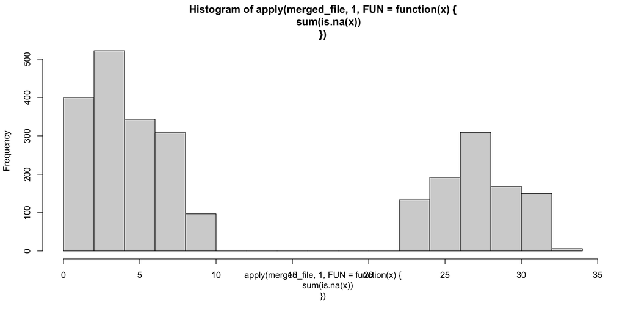

- Change the values for each variable to favoriable format:

```
##
##    Evidence No_evidence     Unknown
##         106        1544         978
```

```
## Cancer.Status.f
## No_evidence    Evidence     Unknown
##        1544         106         978
```

```
## stage.f
##    1    2    3
## 1507  841  280
```

```
## age.f
##    0    1
## 1666  962
```

```
##
##   Black   Other Unknown   White
##     735      44     130    1719
```

```
## race.f
##   White   Black   Other Unknown
##    1719     735      44     130
```

```
## marital.status.f
##  Married Divorced   Single  Unknown  Widowed
##      958      231      245     1001      193
```

```
## Usual.Occupation.f
##   Employed   Disabled    Retired Unemployed    Unknown
##        895         19        127        133       1454
```

```
## Primary.Payer.f
##   Private Insurance  Medicaid   Unknown
##       751       313       582       982
```

```
##
##                      Never used tobacco   Presently smokes
##                 1050                  415                   59
## Smoked and chewed or Smoked in the past   Smoked in the past,
##                    4                  134                    1
## Tobacco use positive Unknown
##                    2                    5
```

```
##
##   Never  Smoked Unknown
##     415     200    2013
```

```
##
##  ductal lobular   Other Unknown
##    1425     201      44     958
```

```
##
##        Borderline   Negative/Normal  Negative/Normal  Positive/Elevated
##                14               737               417               192
##     test not done     Test not done
##                20               290
```

```
##
##           Negative/Normal         Positive/Elevated Positive/Elevated
##                        28                      1354                       261
##             Test not done
##                        27
```

```
##
##   Negative/Normal  Negative/Normal  Positive/Elevated     Test not done
##               176                81              1380                33
```

```
##
## Distant recurrence of an invasive tumor in a single distant site (51–58) and local, trocar and/or regional recurrence (10–15, 20–25, or 30).
##                                                                                                                                                                                                                                                               1
## Distant recurrence of an invasive tumor in bone only. This includes bones other than the primary site.
##                                                                                                                                                                                                                                                              14
## Distant recurrence of an invasive tumor in liver only
##                                                                                                                                                                                                                                                               2
## Distant recurrence of an invasive tumor in multiple sites (recurrences that can be coded to more than one category 51–59).
##                                                                                                                                                                                                                                                               3
## Distant recurrence of an invasive tumor in the CNS only. This includes the brain and spinal cord, but not the external eye.
##                                                                                                                                                                                                                                                               2
## Distant recurrence of an invasive tumor in the lung only. Lung includes the visceral pleura.
##                                                                                                                                                                                                                                                               1
## Distant recurrence of an invasive tumor in the peritoneum only. Peritoneum includes peritoneal surfaces of all structures within the abdominal cavity and/or positive ascitic fluid.
##                                                                                                                                                                                                                                                               1
## Distant recurrence of an invasive tumor in the pleura only. Pleura includes the pleural surface of all structures within the thoracic cavity and/or positive pleural fluid.
##                                                                                                                                                                                                                                                               1
## Distant recurrence, to a site not listed in 46-62 or there is insufficient information available to code to 46–62.
##                                                                                                                                                                                                                                                              20
## Distant systemic recurrence of an invasive tumor only. This includes lymphoma, leukemia, bone marrow metastasis, carcinomatosis, generalized disease.
##                                                                                                                                                                                                                                                               1
## It is unknown whether the disease has recurred or if the patient was ever disease-free
##                                                                                                                                                                                                                                                              35
```

[output cut: 12 more lines]

```
##
## Areola            Breast, axillary  Breast, central p Breast, inner
##                 6                 5                83                18
## Breast, lower     Breast, lower-inn Breast, lower-out Breast, midline o
##                32                97               101                50
## Breast, NOS       Breast, outer     Breast, overlappi Breast, upper
##               242                27               181                57
## Breast, upper-inn Breast, upper-out           Unknown
##               166               605               958
```

```
##
##    Y
## 1190
```

```
##     zip ssn_wcc_num profile_key dx_date_use Marital_Status_at_DX accession_no
## 1 38117   408621384        1665  2009-11-09              Married    201300669
## 2 38111   587863139       73724        <NA>              Unknown           NA
## 3 38138   587848199       73763  2013-11-21              Married    201304565
## 4 38141   587609673       73942  2011-02-24              Married    201100278
## 5 38017   587520329       74069        <NA>              Unknown           NA
## 6 38053   568303662       75696  2014-02-17              Widowed    201401518
##   state                  race_NIH race_simple stage_merged stage_simple gender
## 1    TN                     White       White           IA            1      F
## 2    TN                     White       White         IIIA            3      F
## 3    TN   Unknown or Not Reported     Unknown          IIB            2      F
## 4    TN Black or African American       Black           IA            1      F
## 5    TN                     White       White           II            2      F
## 6    TN   Unknown or Not Reported     Unknown           IA            1      F
##   age_at_dx age_binary first_chemo first_surgery DEPRESSION DIABETES Metastasis
```

[output cut: 69 more lines]

## 2.3 Save the merged data

```r
# write.xlsx(x=merged_file,file=paste0(dataDir,"PatientsData_merged_",today,".xlsx"))
```

## 2.4 Descriptive table

```r
sample0 = which(apply(merged_file,1,FUN=function(x){sum(is.na(x))})==0) # samples with no missing values
cat(paste("Number of samples with no missing =",length(sample0)),"\n")
```

```
## Number of samples with no missing = 238
```

```r
merged_file0 = merged_file[sample0,]
dim(merged_file0)
```

```
## [1] 238  53
```

```r
table(merged_file0$zip)
```

```
##
## 38016 38018 38088 38103 38104 38106 38107 38108 38109 38111 38112 38114 38115
##     6    13     1     1     5     7     8     2    23    11     3     9     5
## 38116 38117 38118 38119 38120 38122 38125 38126 38127 38128 38133 38134 38135
##    10    21     5    11     8    13     5     1     9     7     5    25    16
## 38141
##     8
```

```r
zipcode0 = sort(unique(merged_file0$zip))
# zipcode0 = sort(names(table(merged_file0$zip)[which(table(merged_file0$zip)>5)]))
# merged_file0 = merged_file0[which(merged_file0$zip %in% zipcode),]
# table(merged_file0$zip)
```

```r
sample1 = which(apply(merged_file[,c(3,4,31:34)],1,FUN=function(x){sum(is.na(x))})==0) # samples with no missing values in POVERTY
cat(paste("Number of samples with no missing =",length(sample1)),"\n")
```

```
## Number of samples with no missing = 1666
```

```r
merged_file1 = merged_file[sample1,]
dim(merged_file1)
```

```
## [1] 1666   53
```

```r
table(merged_file1$zip)
```

```
##
## 37058 37075 37090 37174 37186 37206 37218 37882 38002 38004 38006 38008 38011
##     1     1     1     1     1     1     1     1    68    18     1     1    14
## 38012 38015 38016 38017 38018 38019 38023 38024 38027 38028 38029 38034 38037
##     6     1    64   101    59    16     8    13     1    20     3     1     1
## 38039 38040 38041 38046 38049 38052 38053 38057 38058 38059 38060 38063 38066
##     2     5     2     2     6     6    43     4    22     4    16     7     4
## 38067 38068 38069 38075 38079 38080 38083 38088 38103 38104 38105 38106 38107
##     2    21     3     5     1     1     1     1    12    30     3    24    23
## 38108 38109 38111 38112 38114 38115 38116 38117 38118 38119 38120 38122 38124
##    13    70    49    21    32    30    45    68    30    42    45    40     1
## 38125 38126 38127 38128 38130 38133 38134 38135 38138 38139 38141 38167 38168
##    50     6    46    41     1    26    67    44    86    47    21     2     1
## 38173 38174 38183 38184 38186 38187 38201 38221 38222 38229 38237 38242 38255
##     1     1     1     1     2     2     5     3     1     1     2     5     1
## 38256 38261 38301 38305 38310 38316 38320 38326 38329 38333 38334 38339 38340
##     1     3     3     7     5     2     1     2     1     1     1     2     1
## 38343 38344 38351 38355 38357 38358 38367 38368 38372 38375 38379 38381 38382
##     1     1     2     1     3     1     5     1     7     6     1     1     1
## 38387
##     1
```

```r
zipcode1 = sort(unique(merged_file1$zip))
# zipcode1 = sort(names(table(merged_file1$zip)[which(table(merged_file1$zip)>5)]))
# merged_file1 = merged_file1[which(merged_file1$zip %in% zipcode1),]
# table(merged_file1$zip)
```

# 3 PCM data (pain perception)

Goal. PCM + dx_date_use + first_chemo + first_surgery

- Remove duplicates from PCM file (N=3835)

```r
rm(pcm_file)
pcm_file_original = read.xlsx(xlsxFile=paste0(dataDir,"pcm.xlsx"),sheet=1,detectDates=TRUE)
pcm_file = pcm_file_original
dim(pcm_file)
```

```
## [1] 82216     3
```

```r
length(unique(pcm_file$profile_key))
```

```
## [1] 3835
```

```r
pcm_uniq1 = distinct(pcm_file)
dim(pcm_uniq1)
```

```
## [1] 58650     3
```

```r
length(unique(pcm_uniq1$profile_key))
```

```
## [1] 3835
```

- Remove samples that are not in PatientVar profile

```
## Number of patients in PCM profile but not in PatientVar profile =  1207
```

```
## Number of patients in PatientVar profile but not in PCM profile =  0
```

```
## [1] 39019     3
```

```
## [1] 2628
```

- Remove NAs from PCM file

```
## [1] 919
```

```
## [1] 38100     3
```

```
## [1] 2412
```

```
## Number of patients in PatientVar profile but not in PCM profile =  216
```

- Put dx_date_use to the closest survey date in PCM file.

```
## Number of patients in PCM with dx_date not available = 113
```

```
## Number of patients in PCM with dx_date available = 2299
```

- Put first_chemo to the closest survey date in PCM file.

```
## Number of patients in PCM with first_chemo not available = 623
```

```
## Number of patients in PCM with first_chemo available = 1789
```

- Put first_surgery to the closest survey date in PCM file.

```
## Number of patients in PCM with first_surgery not available = 1252
```

```
## Number of patients in PCM with first_surgery available = 1160
```

```
##   profile_key SURVEY_DATE a_CCMA06    dx_date dx_diff_days first_chemo_date
## 1        1665  2009-12-01        0 2009-11-09           22       2009-03-27
## 2        1665  2010-03-17        0       <NA>          128             <NA>
## 3        1665  2010-09-15        2       <NA>          310             <NA>
## 4        1665  2010-10-27        0       <NA>          352             <NA>
## 5        1665  2011-01-12        0       <NA>          429             <NA>
## 6        1665  2011-07-20        0       <NA>          618             <NA>
##   chemo_diff_days first_surgery_date surgery_diff_days
## 1             249         2009-10-13                49
## 2             355               <NA>               155
## 3             537               <NA>               337
## 4             579               <NA>               379
## 5             656               <NA>               456
## 6             845               <NA>               645
```

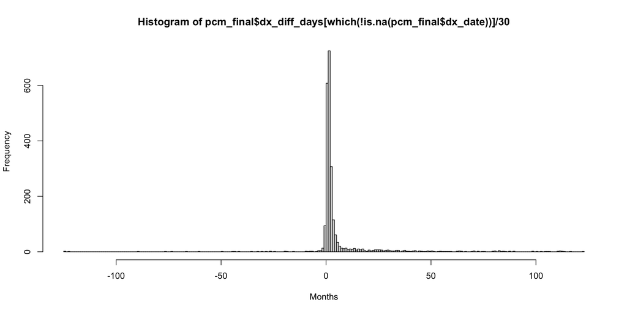

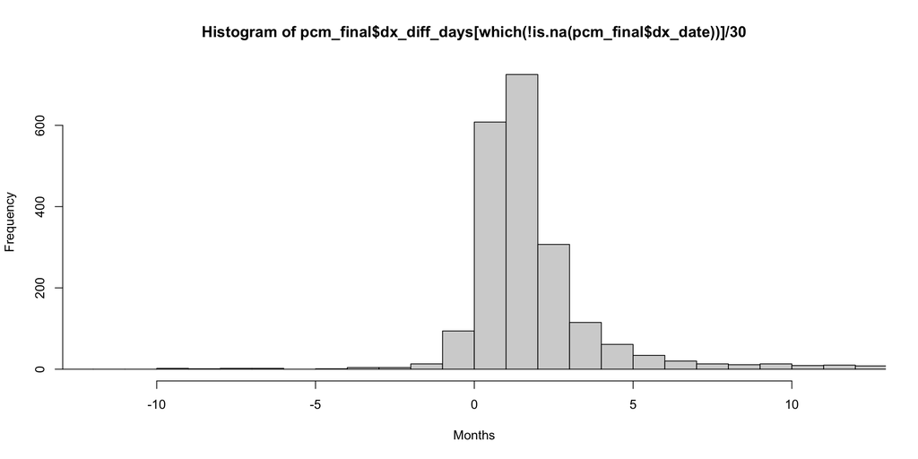

```
## Number of patients within 30-day window = 682
```

```
## Number of patients within 60-day window = 1420
```

```
## Number of patients within 90-day window = 1743
```

```r
# write.xlsx(x=pcm_final,file=paste0(dataDir,"PCM_Dates_merged_",today,".xlsx"))
```